# 0 导入数据

```python
import pandas as pd
import numpy as np
import matplotlib.pyplot as plt
import matplotlib
matplotlib.rcParams['font.family'] = 'SimHei'
matplotlib.rcParams['axes.unicode_minus'] = False # 解决保存图像是负号'-'显示为方块的问题

%load_ext autoreload
%autoreload 2

# from utils.utils import plot_pred, plot_pred_scatter, plot_importance, calc_metrics
```

```python
data = pd.read_excel('./ShearCapacityYu_final.xlsx')
data = data.loc[data['fyv[MPa]'] == 0, :] # 仅适用无箍筋数据
data = data.drop(['rho_sv[%]', 'fyv[MPa]'], axis=1)  # 去掉'横向配筋率', '横向钢筋屈服强度' 两列
data = data.loc[data['rho_s[%]'] != 1.88, :] # Choi and Yun [30]的14条数据比较怪异，剔除试一下

# 仅适用rho_s
# data = data.iloc[:, [-5, -1]]
```

```python
data_4show = pd.read_excel(r'D:\000data\YuShearStrength\ShearCapacityYu_final.xlsx')
data_4show = data_4show.loc[data_4show['fyv[MPa]'] == 0, :] # 仅适用无箍筋数据
name_eng = list(data_4show.columns)
name_cn = ['截面宽度', '界面高度', '有效截面高度','剪跨比', 'RA的替换率', '水灰比', '试件最大尺寸', '抗压强度', '纵向配筋率', '纵向钢筋屈服强度', '横向配筋率', '横向钢筋屈服强度', '抗剪强度']
# name_cn = ['截面宽度', '界面高度', '有效截面高度','剪跨比', 'RA的替换率', '水灰比', '试件最大尺寸', '抗压强度', '纵向配筋率', '纵向钢筋屈服强度', '抗剪强度']
data_4show.columns = [name_eng, name_cn]
```

# 1. 数据分析（Exploratory Data Analysis, EDA）

特征(feature)及目标(target)：

- 输入数据维度为264x13，（206个数据没有箍筋，58个有箍筋）
- 其中前12项为训练需要的特征--feature
- 最后1项为需要预测的目标--target

## 1.1 数据分布

```python
print("Shape of data: ", data_4show.shape)
data_4show
```

```
Shape of data:  (206, 13)
```

|  | b[mm] 截面宽度 | h[mm] 界面高度 | d[mm] 有效截面高度 | a/d 剪跨比 | r RA的替换率 | w/c 水灰比 | smax[mm] 试件最大尺寸 | fc[MPa] 抗压强度 | rho_s[%] 纵向配筋率 | fy[MPa] 纵向钢筋屈服强度 | rho_sv[%] 横向配筋率 | fyv[MPa] 横向钢筋屈服强度 | Vu[kN] 抗剪强度 |
| --- | --- | --- | --- | --- | --- | --- | --- | --- | --- | --- | --- | --- | --- |
| 0 | 170 | 300 | 270 | 1.50 | 1.00 | 0.4 | 25.0 | 39.6 | 1.11 | 430 | 0.0 | 0 | 144.1 |
| 1 | 170 | 300 | 270 | 2.00 | 1.00 | 0.4 | 25.0 | 30.6 | 1.11 | 430 | 0.0 | 0 | 117.5 |
| 2 | 170 | 300 | 270 | 3.00 | 1.00 | 0.4 | 25.0 | 31.2 | 1.11 | 430 | 0.0 | 0 | 55.1 |
| 3 | 170 | 300 | 270 | 4.00 | 1.00 | 0.4 | 25.0 | 31.9 | 1.11 | 430 | 0.0 | 0 | 50.9 |
| 4 | 170 | 300 | 270 | 2.00 | 1.00 | 0.4 | 25.0 | 32.6 | 1.11 | 430 | 0.0 | 0 | 113.4 |
| ... | ... | ... | ... | ... | ... | ... | ... | ... | ... | ... | ... | ... | ... |
| 234 | 150 | 300 | 267 | 1.85 | 0.50 | 0.5 | 31.5 | 23.7 | 0.90 | 370 | 0.0 | 0 | 165.0 |
| 235 | 150 | 300 | 267 | 1.85 | 0.50 | 0.5 | 31.5 | 23.7 | 0.90 | 370 | 0.0 | 0 | 160.0 |
| 236 | 150 | 300 | 267 | 1.85 | 0.75 | 0.5 | 31.5 | 23.4 | 0.90 | 370 | 0.0 | 0 | 152.0 |
| 237 | 150 | 300 | 267 | 1.85 | 0.75 | 0.5 | 31.5 | 23.4 | 0.90 | 370 | 0.0 | 0 | 142.0 |
| 238 | 150 | 300 | 267 | 1.85 | 0.75 | 0.5 | 31.5 | 23.4 | 0.90 | 370 | 0.0 | 0 | 155.0 |

206 rows × 13 columns

```python
data_4show.describe()
```

|  | b[mm] 截面宽度 | h[mm] 界面高度 | d[mm] 有效截面高度 | a/d 剪跨比 | r RA的替换率 | w/c 水灰比 | smax[mm] 试件最大尺寸 | fc[MPa] 抗压强度 | rho_s[%] 纵向配筋率 | fy[MPa] 纵向钢筋屈服强度 | rho_sv[%] 横向配筋率 | fyv[MPa] 横向钢筋屈服强度 | Vu[kN] 抗剪强度 |
| --- | --- | --- | --- | --- | --- | --- | --- | --- | --- | --- | --- | --- | --- |
| count | 206.000000 | 206.000000 | 206.000000 | 206.000000 | 206.000000 | 206.000000 | 206.000000 | 206.000000 | 206.000000 | 206.000000 | 206.0 | 206.0 | 206.000000 |
| mean | 207.970874 | 365.990291 | 320.150485 | 2.829806 | 0.550340 | 0.480049 | 22.131068 | 33.068447 | 1.687476 | 465.325243 | 0.0 | 0.0 | 124.340777 |
| std | 73.007244 | 121.550391 | 108.905471 | 0.915758 | 0.403357 | 0.062387 | 4.270124 | 6.765791 | 0.735822 | 89.243903 | 0.0 | 0.0 | 114.333502 |
| min | 100.000000 | 120.000000 | 105.000000 | 1.000000 | 0.000000 | 0.340000 | 12.500000 | 22.600000 | 0.530000 | 331.000000 | 0.0 | 0.0 | 12.100000 |
| 25% | 150.000000 | 300.000000 | 260.000000 | 2.000000 | 0.062500 | 0.440000 | 19.000000 | 28.150000 | 1.072500 | 414.000000 | 0.0 | 0.0 | 56.175000 |
| 50% | 200.000000 | 350.000000 | 300.000000 | 2.600000 | 0.500000 | 0.460000 | 20.000000 | 32.600000 | 1.615000 | 444.500000 | 0.0 | 0.0 | 92.900000 |
| 75% | 200.000000 | 420.000000 | 388.000000 | 3.250000 | 1.000000 | 0.500000 | 25.000000 | 37.300000 | 1.990000 | 534.000000 | 0.0 | 0.0 | 150.000000 |
| max | 400.000000 | 680.000000 | 600.000000 | 5.000000 | 1.000000 | 0.600000 | 31.500000 | 49.100000 | 4.090000 | 651.000000 | 0.0 | 0.0 | 862.700000 |

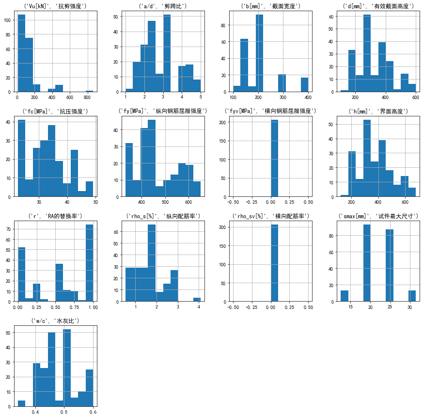

```python
data_4show.hist(figsize=(15, 15))
plt.show()
```

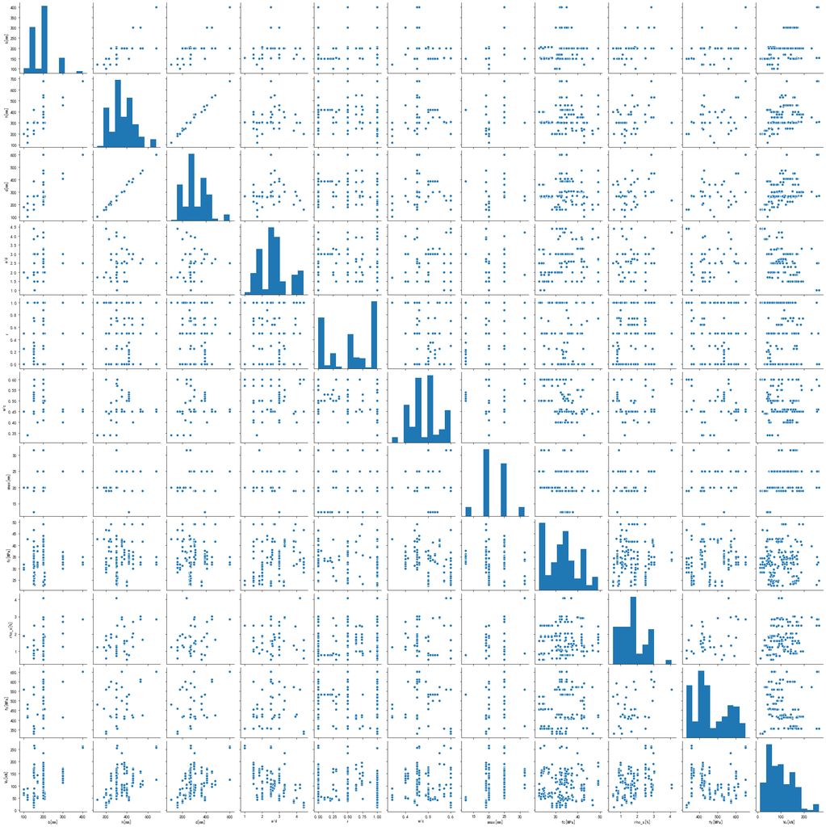

```python
import seaborn as sns
columns_list = ['b[mm]', 'h[mm]', 'd[mm]', 'a/d', 'r', 'w/c', 'smax[mm]', 'fc[MPa]', 'rho_s[%]', 'fy[MPa]', 'rho_sv[%]', 'fyv[MPa]', 'Vu[kN]']
sns.pairplot(data)
```

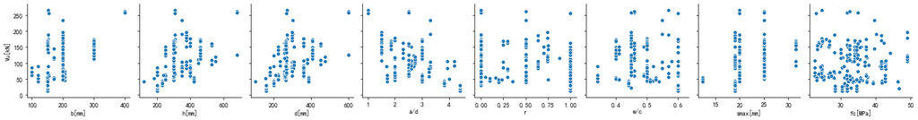

```python
sns.pairplot(data=data, y_vars=['Vu[kN]'], x_vars=['b[mm]', 'h[mm]', 'd[mm]', 'a/d', 'r', 'w/c', 'smax[mm]', 'fc[MPa]'])
```

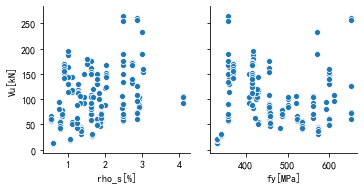

```python
sns.pairplot(data=data, y_vars=['Vu[kN]'], x_vars=['rho_s[%]', 'fy[MPa]'])
```

## 1.2 相关性分析

```python
data.corr()
```

|  | b[mm] | h[mm] | d[mm] | a/d | r | w/c | smax[mm] | fc[MPa] | rho_s[%] | fy[MPa] | Vu[kN] |
| --- | --- | --- | --- | --- | --- | --- | --- | --- | --- | --- | --- |
| b[mm] | 1.000000 | 0.675237 | 0.653207 | -0.034367 | -0.077485 | -0.391297 | 0.346731 | 0.033445 | 0.385970 | 0.161799 | 0.507397 |
| h[mm] | 0.675237 | 1.000000 | 0.993229 | -0.184992 | -0.203690 | -0.247497 | 0.198336 | -0.065408 | 0.309239 | 0.285231 | 0.469428 |
| d[mm] | 0.653207 | 0.993229 | 1.000000 | -0.213469 | -0.217574 | -0.255105 | 0.186060 | -0.109424 | 0.261359 | 0.306610 | 0.448985 |
| a/d | -0.034367 | -0.184992 | -0.213469 | 1.000000 | 0.129352 | 0.226907 | -0.204011 | 0.274593 | -0.030407 | -0.004784 | -0.560446 |
| r | -0.077485 | -0.203690 | -0.217574 | 0.129352 | 1.000000 | 0.019900 | -0.016508 | 0.048995 | -0.069880 | -0.188976 | -0.187149 |
| w/c | -0.391297 | -0.247497 | -0.255105 | 0.226907 | 0.019900 | 1.000000 | -0.124336 | -0.357781 | 0.073866 | -0.297550 | -0.204304 |
| smax[mm] | 0.346731 | 0.198336 | 0.186060 | -0.204011 | -0.016508 | -0.124336 | 1.000000 | -0.349108 | 0.279827 | -0.081267 | 0.467691 |
| fc[MPa] | 0.033445 | -0.065408 | -0.109424 | 0.274593 | 0.048995 | -0.357781 | -0.349108 | 1.000000 | 0.023430 | 0.195218 | -0.024403 |
| rho_s[%] | 0.385970 | 0.309239 | 0.261359 | -0.030407 | -0.069880 | 0.073866 | 0.279827 | 0.023430 | 1.000000 | 0.241325 | 0.374270 |
| fy[MPa] | 0.161799 | 0.285231 | 0.306610 | -0.004784 | -0.188976 | -0.297550 | -0.081267 | 0.195218 | 0.241325 | 1.000000 | -0.045426 |
| Vu[kN] | 0.507397 | 0.469428 | 0.448985 | -0.560446 | -0.187149 | -0.204304 | 0.467691 | -0.024403 | 0.374270 | -0.045426 | 1.000000 |

```python
data.corr()['Vu[kN]'].sort_values()
```

```
a/d        -0.560446
w/c        -0.204304
r          -0.187149
fy[MPa]    -0.045426
fc[MPa]    -0.024403
rho_s[%]    0.374270
d[mm]       0.448985
smax[mm]    0.467691
h[mm]       0.469428
b[mm]       0.507397
Vu[kN]      1.000000
Name: Vu[kN], dtype: float64
```

# 2. 准备数据集(划分训练集和测试集)

## 2.1 标准化(Standardization)

原因：如果一个特征的方差远大于其他特征，它可能主导目标函数，使模型无法正确地从其他特征中学习优化。例如水灰比平均值在0.5附近，而截面高度平均值在350附近，可能导致模型被截面高度参数主导。

```python
X = data.iloc[:, 0:-1]
y = data.iloc[:,-1]
```

```python
X.describe()
```

|  | b[mm] | h[mm] | d[mm] | a/d | r | w/c | smax[mm] | fc[MPa] | rho_s[%] | fy[MPa] |
| --- | --- | --- | --- | --- | --- | --- | --- | --- | --- | --- |
| count | 192.00000 | 192.000000 | 192.000000 | 192.000000 | 192.000000 | 192.000000 | 192.000000 | 192.000000 | 192.000000 | 192.000000 |
| mean | 193.96875 | 348.927083 | 305.213542 | 2.731458 | 0.539427 | 0.482969 | 21.921875 | 33.240104 | 1.673437 | 467.682292 |
| std | 53.11086 | 107.475140 | 97.106253 | 0.821143 | 0.402716 | 0.063650 | 4.350079 | 6.944040 | 0.760399 | 92.011313 |
| min | 100.00000 | 120.000000 | 105.000000 | 1.000000 | 0.000000 | 0.340000 | 12.500000 | 22.600000 | 0.530000 | 331.000000 |
| 25% | 150.00000 | 300.000000 | 260.000000 | 2.000000 | 0.000000 | 0.450000 | 19.000000 | 26.950000 | 1.060000 | 407.000000 |
| 50% | 200.00000 | 308.500000 | 271.500000 | 2.590000 | 0.500000 | 0.490000 | 20.000000 | 33.250000 | 1.610000 | 456.000000 |
| 75% | 200.00000 | 400.000000 | 360.000000 | 3.000000 | 1.000000 | 0.500000 | 25.000000 | 37.400000 | 2.030000 | 540.500000 |
| max | 400.00000 | 680.000000 | 600.000000 | 4.400000 | 1.000000 | 0.600000 | 31.500000 | 49.100000 | 4.090000 | 651.000000 |

```python
from sklearn.preprocessing import StandardScaler
scaler = StandardScaler()
scaler.fit(X)
X = scaler.transform(X)
pd.DataFrame(X, columns=data.columns[:-1]).iloc[10:15,:]
```

|  | b[mm] | h[mm] | d[mm] | a/d | r | w/c | smax[mm] | fc[MPa] | rho_s[%] | fy[MPa] |
| --- | --- | --- | --- | --- | --- | --- | --- | --- | --- | --- |
| 10 | 0.113857 | 0.010009 | -0.022855 | 0.694189 | -1.342974 | 1.055872 | 0.709452 | 1.004904 | 1.722752 | 1.125816 |
| 11 | 0.113857 | 0.010009 | -0.022855 | 0.694189 | -0.098159 | 1.055872 | 0.709452 | 0.932711 | 1.722752 | 1.125816 |
| 12 | 0.113857 | 0.243229 | 0.039095 | -0.172720 | 0.250389 | -0.519322 | -0.673439 | 0.528434 | -0.320982 | -0.661233 |
| 13 | 0.113857 | 0.243229 | 0.039095 | -0.172720 | -1.342974 | -0.519322 | -0.673439 | 0.687257 | -0.320982 | -0.661233 |
| 14 | 0.113857 | 0.243229 | 0.039095 | -0.172720 | -1.342974 | -0.519322 | -0.673439 | 0.384049 | -0.320982 | -0.661233 |

## 2.2 划分训练集和测试集

```python
from sklearn.model_selection import train_test_split

X_train, X_test, y_train, y_test = train_test_split(X, y, random_state=0)
print('X_train shape: ', X_train.shape)
print('y_train shape: ', y_train.shape)
print('X_test shape:  ', X_test.shape)
print('y_test shape:  ', y_test.shape)
```

```
X_train shape:  (144, 10)
y_train shape:  (144,)
X_test shape:   (48, 10)
y_test shape:   (48,)
```

# 3. 模型

## 3.1 首先采用线性回归模型，拟合函数为：

$$\hat{y}(w, x)=w_{0}+w_{1} x_{1}+\ldots+w_{p} x_{p}$$

损失函数为： $$ \min _{w}\|X w-y\|_{2}^{2} $$

```python
from sklearn.linear_model import LinearRegression

# 线性回归模型
model = LinearRegression()
```

## 3.2 采用全连接神经网络，多层感知机（Fully connected neural network, OR, Multi-layer Perceptron regressor）

```python
from sklearn.neural_network import MLPRegressor

# 全连接神经网络模型
# hidden_layer_sizes=(100, 100, 100, 100) hidden层4层,第一层100个神经元，第二层100个神经元
model = MLPRegressor(
    hidden_layer_sizes=(100, 100, 100, 100),  activation='relu', solver='adam', batch_size='auto',
    learning_rate='constant', learning_rate_init=0.01, max_iter=5000, shuffle=True,
    random_state=1, tol=0.0001, verbose=False, warm_start=False, momentum=0.9, nesterovs_momentum=True,
    early_stopping=False,beta_1=0.9, beta_2=0.999, epsilon=1e-08)
```

## 3.3 采用其他模型，以随机森林为例

```python
from sklearn.ensemble import RandomForestRegressor

model = RandomForestRegressor()
```

# 4. 训练

```python
model.fit(X_train, y_train)
```

```
RandomForestRegressor()
```

# 5. 预测和结论分析

## 5.1 预测

```python
y_pred = model.predict(X_test)
```

## 5.2 分析

### 5.2.1 线性回归模型

```python
# 一些绘图的程序，请勿修改
def plot_pred(model, y_test, y_pred, mae, rmse, r2, savepath=None):
    plt.figure(figsize=(20,5))
    plt.grid(axis='x', ls='--')
    ax = plt.gca()
    ax.set_xticks(range(len(y_test)))
    plt.scatter(range(len(y_pred)), y_pred, c='b', label='pred')
    plt.scatter(range(len(y_test.values)), y_test, c='r', label='target')
    plt.legend()
    plt.xlabel('样本')
    plt.ylabel('预测的抗剪承载力')
    plt.title('模型({})的预测结果, mae:{:.2f}, rmse:{:.2f}, r2:{:.2f}'.format(type(model).__name__, mae, rmse, r2))
#     plt.savefig(savepath / '{}.png'.format(type(model).__name__))
    plt.show()

def plot_pred_scatter(model, y_test, y_pred, mae, rmse, r2, savepath=None):
    fig = plt.figure(figsize=(7,7))
    ax = fig.add_subplot()
    plt.plot(range(400), range(400), 'r--')
    plt.scatter(y_test, y_pred)
    plt.title('模型（{}）真实值vs预测值'.format(type(model).__name__))
    plt.xlabel('真实值')
    plt.ylabel('预测值')
    plt.text(0.1, 0.8, s='mae:{:.2f}\nrmse:{:.2f}\nr2:{:.2f}'.format(mae, rmse, r2), transform=ax.transAxes, fontsize=15)
#     plt.savefig(savepath/'{}.png'.format(type(model).__name__))
    plt.show()



def plot_importance(model, colums, savepath=None):
    plt.figure(figsize=(8,4))
    plt.bar(x=colums, height=model.feature_importances_)
    plt.title('参数重要性分析 | {}'.format(type(model).__name__))
    plt.xlabel('参数')
    plt.ylabel('重要性')
#     plt.savefig(savepath/'重要性_{}.png'.format(type(model).__name__))
    plt.show()


def calc_metrics(y_test, y_pred):
    from sklearn.metrics import mean_absolute_error, mean_squared_error, r2_score
    mae = mean_absolute_error(y_test, y_pred)
    rmse = mean_squared_error(y_test, y_pred, squared=False)
    r2 = r2_score(y_test, y_pred)
    return mae, rmse, r2
```

```python
mae, rmse, r2 = calc_metrics(y_test, y_pred)
```

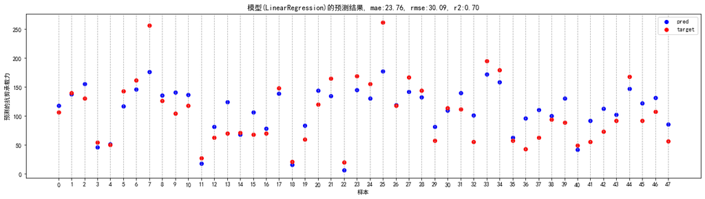

```python
# 每个样本的预测值
plot_pred(model, y_test, y_pred, mae, rmse, r2)
```

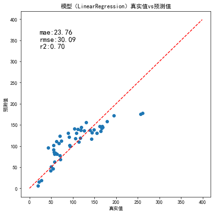

```python
# 绘制预测值与目标值的散点图
plot_pred_scatter(model, y_test, y_pred, mae, rmse, r2)
```

### 5.2.2 多层感知机

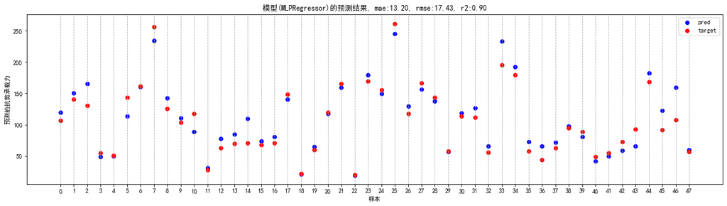

```python
# 每个样本的预测值
plot_pred(model, y_test, y_pred, mae, rmse, r2)
```

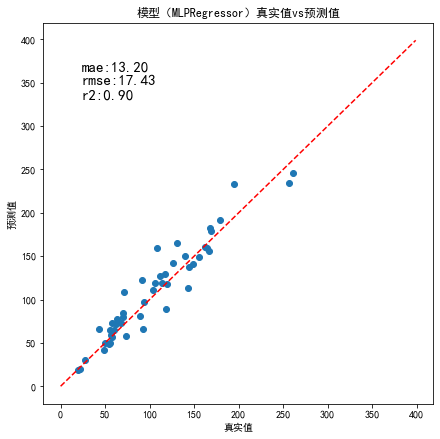

```python
# 绘制预测值与目标值的散点图
plot_pred_scatter(model, y_test, y_pred, mae, rmse, r2)
```

### 5.2.3 其他模型，以随机森林（RandomForest）为例

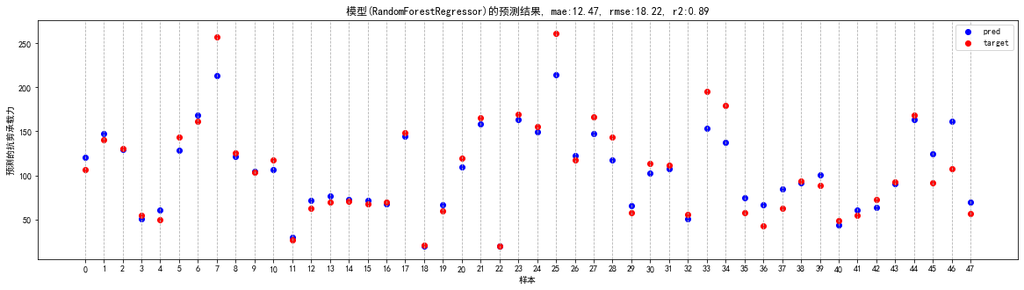

```python
# 每个样本的预测值
plot_pred(model, y_test, y_pred, mae, rmse, r2)
```

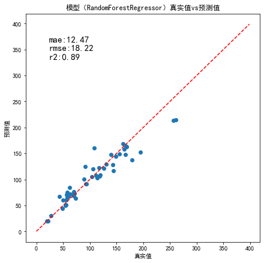

```python
# 绘制预测值与目标值的散点图
plot_pred_scatter(model, y_test, y_pred, mae, rmse, r2)
```

```python
data.columns
```

```
Index(['b[mm]', 'h[mm]', 'd[mm]', 'a/d', 'r', 'w/c', 'smax[mm]', 'fc[MPa]',
       'rho_s[%]', 'fy[MPa]', 'Vu[kN]'],
      dtype='object')
```

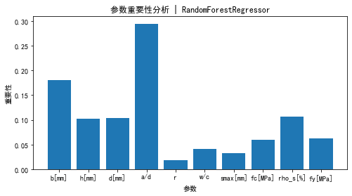

```python
# 树模型有特征重要性
plot_importance(model, list(data.drop('Vu[kN]', axis=1).columns))
```

# 6 思考

1. 如何进行特征工程，例如添加或非线性组合特征？很明显，需要同学对混凝土抗剪具有一定领域知识（domain knowledge）
2. 请同学自己尝试不同的特征工程，观察对模型结果的影响，并结合重要性分析，尝试解释其原因
3. 请同学尝试其他不同模型，并尝试调整超参，以提升精度（提示：对于常见的机器学习模型，目前一般GBDT类的模型（GBDT、XGBoost、LightGBM等）表现较好）